# Activity monitoring

Loading required libraries:

```r
library(dplyr)
library(ggplot2)
```

## Loading and preprocessing the data

Let’s load the data and convert string variable “data” to Date format

```r
activity <- read.csv('activity.csv')
activity$date<-as.Date(activity$date)
head(activity)
```

```
##   steps       date interval
## 1    NA 2012-10-01        0
## 2    NA 2012-10-01        5
## 3    NA 2012-10-01       10
## 4    NA 2012-10-01       15
## 5    NA 2012-10-01       20
## 6    NA 2012-10-01       25
```

```r
class(activity[1,2])
```

```
## [1] "Date"
```

## What is mean total number of steps taken per day?

Calculate the total number of steps taken per day:

```r
totalSteps <- summarise(group_by(activity, date), total_steps=sum(steps))
head(totalSteps)
```

```
## # A tibble: 6 x 2
##         date total_steps
##       <date>       <int>
## 1 2012-10-01          NA
## 2 2012-10-02         126
## 3 2012-10-03       11352
## 4 2012-10-04       12116
## 5 2012-10-05       13294
## 6 2012-10-06       15420
```

Difference between histogram and barplot:

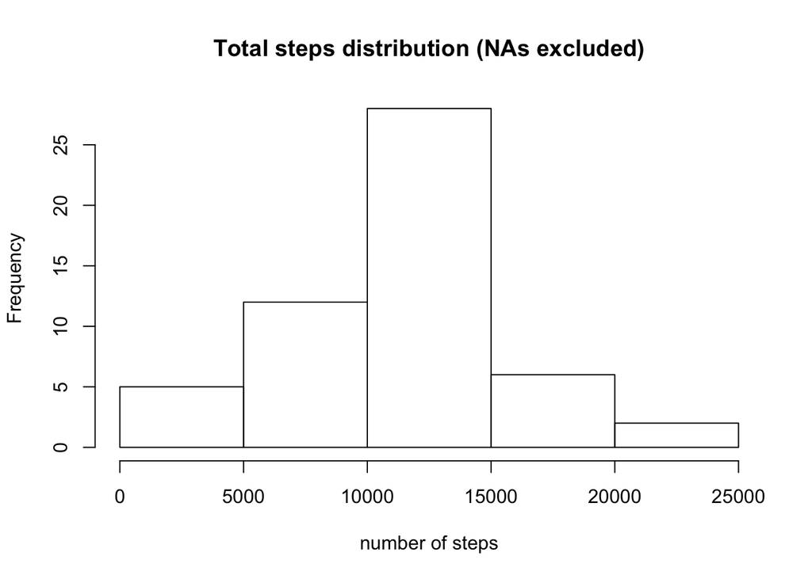

```r
hist(totalSteps$total_steps, main = "Total steps distribution (NAs excluded)",
     xlab = "number of steps")
```

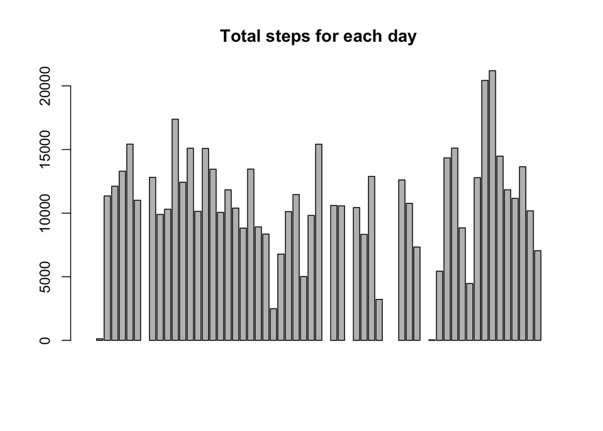

```r
barplot(totalSteps$total_steps, main = "Total steps for each day")
```

Calculate and report the mean and median of the total number of steps taken per day:

```r
mean(totalSteps$total_steps, na.rm = TRUE)
```

```
## [1] 10766.19
```

```r
median(totalSteps$total_steps, na.rm = TRUE)
```

```
## [1] 10765
```

## What is the average daily activity pattern?

Time series plot (i.e. 𝚝𝚢𝚙𝚎 = “𝚕”) of the 5-minute interval (x-axis) and the average number of steps taken, averaged across all days (y-axis):

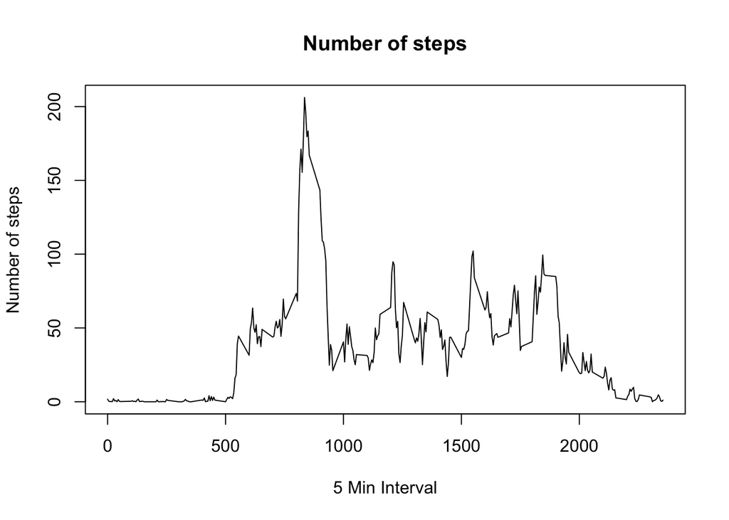

```r
fiveMinAveraged <- summarise(group_by(activity, interval), avg_steps=mean(steps, na.rm = TRUE))
plot(fiveMinAveraged$interval, fiveMinAveraged$avg_steps, type='l',
     main = "Number of steps", xlab='5 Min Interval', ylab = 'Number of steps')
```

Which 5-minute interval, on average across all the days in the dataset, contains the maximum number of steps?

```r
fiveMinAveraged[which(fiveMinAveraged$avg_steps == max(fiveMinAveraged$avg_steps)),1]
```

```
## # A tibble: 1 x 1
##   interval
##      <int>
## 1      835
```

## Imputing missing values

Calculate and report the total number of missing values in the dataset (i.e. the total number of rows with 𝙽𝙰s)

```r
sum(is.na(activity$steps))
```

```
## [1] 2304
```

Let’s replace missing values with average for 5 min interval

```r
for (i in fiveMinAveraged$interval) {
    activity[is.na(activity$steps) & activity$interval==i, 1] <-
      fiveMinAveraged[fiveMinAveraged$interval==i,2]
}
```

Make a histogram of the total number of steps taken each day and Calculate and report the mean and median total number of steps taken per day.

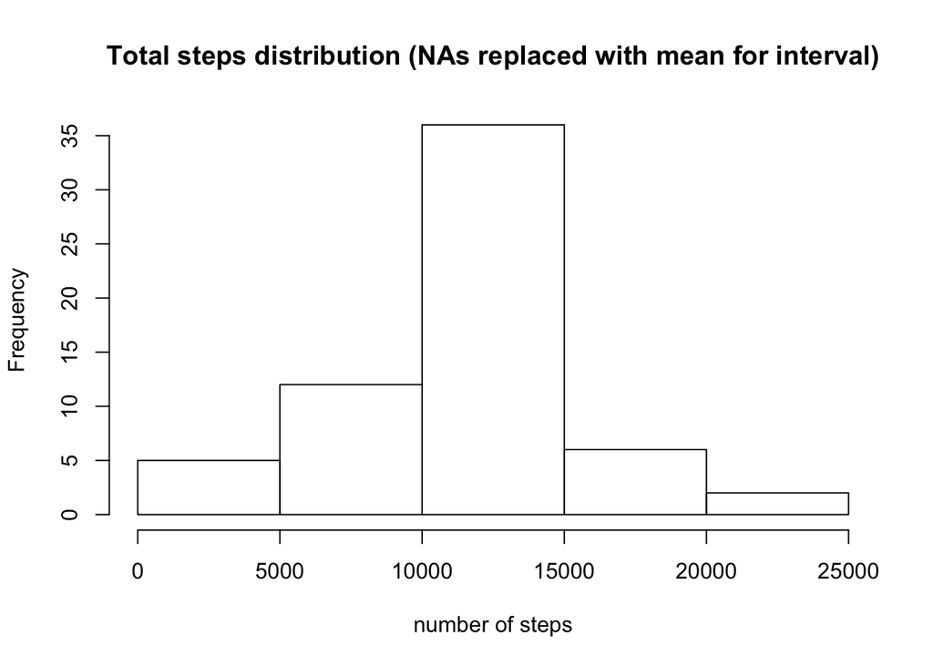

```r
totalSteps <- summarise(group_by(activity, date), total_steps=sum(steps))
hist(totalSteps$total_steps, main = "Total steps distribution (NAs replaced with mean for interval)",
     xlab = "number of steps")
```

```r
mean(totalSteps$total_steps)
```

```
## [1] 10766.19
```

```r
median(totalSteps$total_steps)
```

```
## [1] 10766.19
```

As we see, this NA-filling strategy does not impact on average values significantly

## Are there differences in activity patterns between weekdays and weekends?

Create a new factor variable in the dataset with two levels – “weekday” and “weekend” indicating whether a given date is a weekday or weekend day.

```r
activity$weekday <- weekdays(activity$date)
activity$weekday.type <- ifelse(activity$weekday == "суббота" | activity$weekday ==
                             "воскресенье", "Weekend", "Weekday")
activity$weekday.type <- factor(activity$weekday.type)
```

Time series plot (i.e. 𝚝𝚢𝚙𝚎 = “𝚕”) of the 5-minute interval (x-axis) and the average number of steps taken, averaged across all weekday days or weekend days (y-axis).

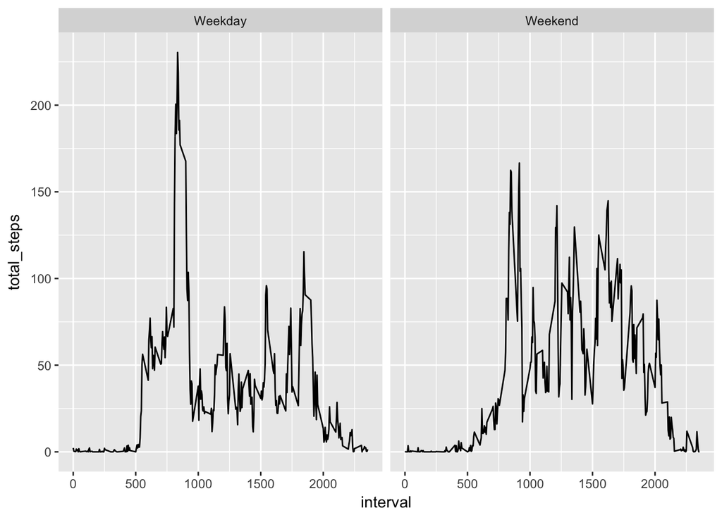

```r
fiveMinWdAvg <- summarise(group_by(activity, interval, weekday.type), total_steps=mean(steps))
ggplot(fiveMinWdAvg,aes(x=interval, y=total_steps))+geom_line()+facet_grid(~weekday.type)
```